# Polymath again and differently

- Research at the intersection of *Internal/External divide* and *Foundations and Practice* areas of this project.
- *Officially* part of modelling of mathematical practice and problem-solving network, but I'd rather think of it as a formal as well as data-driven study of mathematical communities and interaction.
- Research started last year, but it is a continuation of earlier work with Bart and Jean Paul.
- Used scientific Python tools (`pandas`, `networkx`, `BeautifullSoup`, `matplotlib` and `Seaborn`) to study the interaction on the Polymath-blogs.
- The bulk of the progress was only made in the last 6 months, and I'm still working on it.

[figure not shown]

## Why digg once more into Polymath?

- Prior work exists, but it remains inconclusive (descriptions without much "insight" that could inform philosophical projects
- Still active and growing...
  - Polymath 10 on the "Erdos-Rado Sunflower problem" (Gil Kalai) started in November 2015.
  - Polymath 11 on "Frankl’s union-closed conjecture" (Gowers) officially started less than two weeks ago (grrr...)
- Large repository of mathmatics in action *and* reflections on the project itself.
- Usefull data to start from if we want to model mathematical practices.
- We now know a lot more about e-research, and the study of online communities.
- Study Polymath as a research-community.

## Interesting synergies between fields of study

### Content

- Philosophy of mathematical practice
- Social epistemology and the study of scientific communities
- Sociology of e-research

### Methodology

- Computational social-science
- Formal models of interaction

### Two types of interaction

- Data as starting point for formal modelling.
- Formal insights as theory to inform network-analysis and other types of data-driven analysis.

## "Small data," lots of pictures...

### Overview of the Polymath-projects

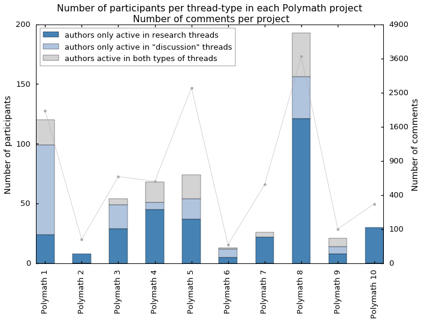

```python
matplotlib.style.use('seaborn-talk')
axes = data.plot(kind='bar', stacked=True, color=['steelblue', 'lightsteelblue', 'lightgrey'],
          title="Number of participants per thread-type in each Polymath project\n Number of comments per project")
axes.set_ylabel("Number of participants")
data2 = np.sqrt(COMMENTS)
axes2 = axes.twinx()
axes2.yaxis.set_major_formatter(FuncFormatter(lambda x, pos:"{:0.0f}".format(np.square(x))))
axes2.set_ylabel("Number of comments")
axes2.plot(axes.get_xticks(), data2.values,
                   linestyle='-', marker='.', linewidth=.5,
                   color='darkgrey')
```

### Overview of the mini-projects

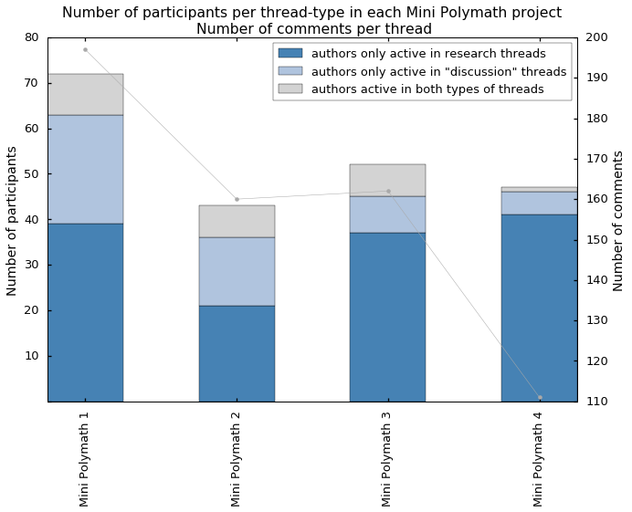

```python
matplotlib.style.use('seaborn-talk')
axes = data.plot(kind='bar', stacked=True, color=['steelblue', 'lightsteelblue', 'lightgrey'],
          title="Number of participants per thread-type in each Mini Polymath project\n Number of comments per thread")
axes.set_ylabel("Number of participants")
axes.yaxis.get_major_ticks()[0].label1.set_visible(False)
data2 = COMMENTS
axes2 = axes.twinx()
axes2.set_ylabel("Number of comments")
axes2.plot(axes.get_xticks(), data2.values,
                   linestyle='-', marker='.', linewidth=.5,
                   color='darkgrey')
```

### Community-evolution

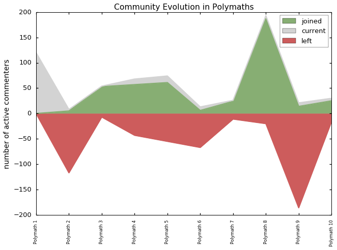

```python
plot_community_evolution("Polymaths")
```

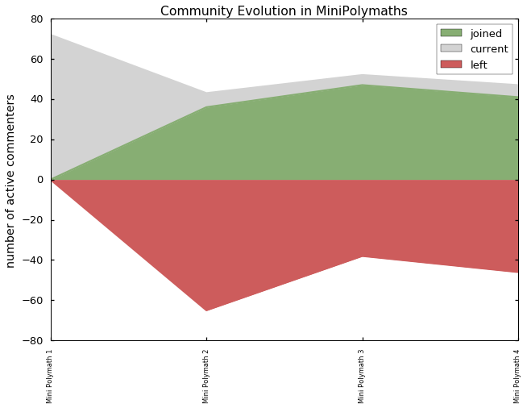

```python
plot_community_evolution("MiniPolymaths")
```

### Who stays, who leaves

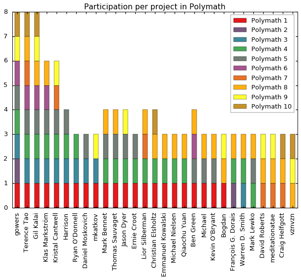

```python
plot_participation_evolution("Polymath", n=3)
```

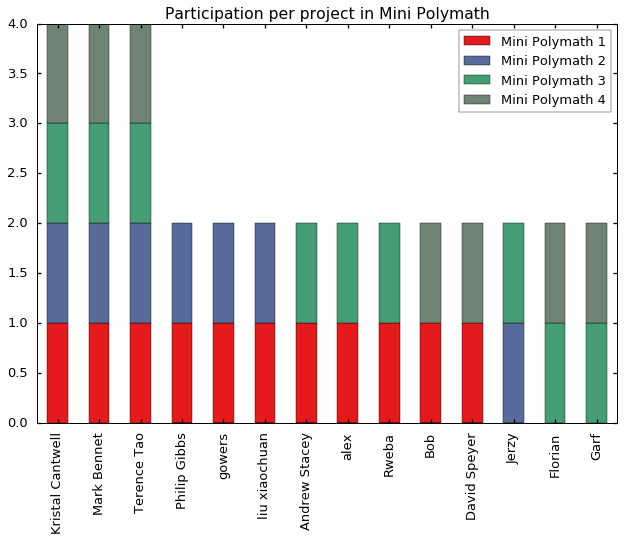

```python
plot_participation_evolution("Mini Polymath", n=2)
```

### Some specific insights

#### Polymath 1 was *special*

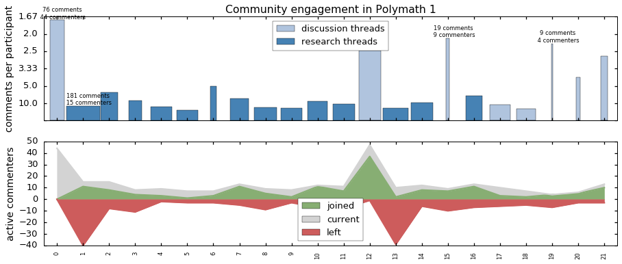

```python
plot_thread_evolution("Polymath 1", compress=140, sel=[0, 1, 15, 19], sharex=True)
```

### Small and large projects are successful

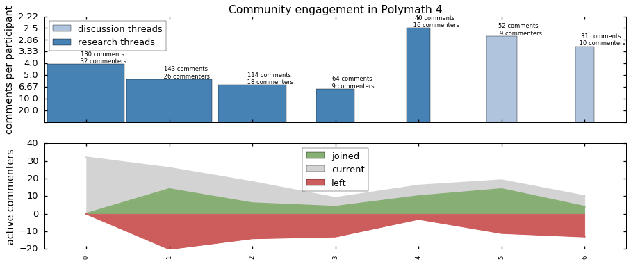

```python
plot_thread_evolution("Polymath 4", compress=140, sel=[0, 1, 2, 3, 4, 5, 6], sharex=True)
```

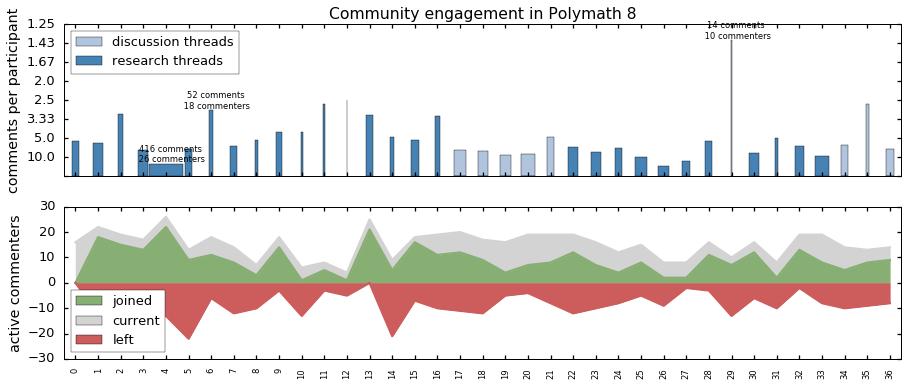

```python
plot_thread_evolution("Polymath 8", compress=280, sel=[4, 6, 29], sharex=True)
```

### Roles and changes over time

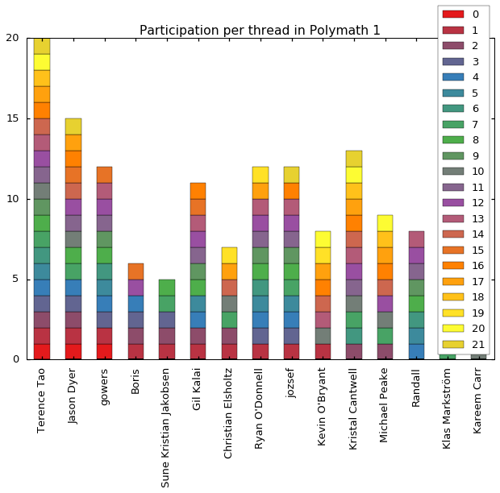

```python
plot_participation_evolution("Polymath 1", n=5)
```

## Typologies of social communities

### Graph-based typologies

- Which structures of communities are successful under which circumstances.
- Two communities are different if their DiGraph are different.
- Typical results: Maximal information-flow is not optimal.

### A typology based on announcement-types

- Who can address which sub-groups?
- Who can make public announcements?
- Account for higher-order information.
- Better suited to explain team-work:
  - Mutual intentions
  - Common intentions
  - Group commitments

### Insights from social network analysis

- Affiliation and interaction-networks
- Measures of degree-centrality

### Applied to Polymath

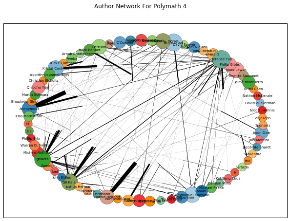

```python
draw_network("Polymath 4")
```

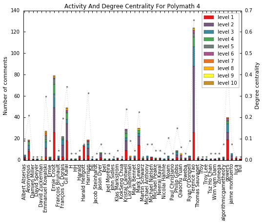

```python
plot_activity_degree("Polymath 4")
```

## Teamwork versus asynchronous communication

- Teamwork requires common information
- But asynchronous communication gets in the way

## What lies ahead

### Several presentations

- TOCAI-seminar at Middlesex London (next week).
- IACAP (submitted).
- ...

### Issues and experimental features

- "Implicit" references to other comments
- Natural language analysis and clustering

### Develop the link with sociological aspect

- Link with e-research and citizen-science.
- Logic as a tool in computational social science.